# Sorpresas inflacionarias y volatilidad del S&P Merval en Argentina (2021-2025)

Metodología y resultados (versión 2: datos Bloomberg y REM del mismo mes)

Luis E. Peñafiel Ch.

2026-11-12

# 2. Metodología

## 2.1 Datos y construcción de variables

### 2.1.1 Fuentes

Los precios diarios del índice S&P Merval y de siete acciones de su panel (GGAL, BMA, YPFD, PAMP, CEPU, TXAR y ALUA) provienen de Bloomberg (`PX_LAST`). El tipo de cambio contado con liquidación (CCL) se construye como cociente entre la cotización de Grupo Financiero Galicia en BYMA y su ADR en NYSE (diez acciones por ADR). El VIX se toma de Yahoo Finance; el IPC, de INDEC (Nivel General, cobertura Nacional); las expectativas de inflación, del Relevamiento de Expectativas de Mercado (REM) del BCRA; el riesgo país (EMBI), de Ámbito; y el dólar oficial, del Banco Nación.

La descarga de Bloomberg del Merval termina el 30 de diciembre de 2025. El tramo hasta el 27 de febrero de 2026, necesario para la ventana del último evento, se completó con Yahoo Finance; con el mismo criterio se reemplazó el cierre del 13 de octubre de 2025, que Bloomberg repite del día hábil anterior. La Tabla 1 documenta que ambas fuentes son prácticamente idénticas, por lo que el empalme no introduce un quiebre.

**Tabla 1.** Comparación del S&P Merval diario según Bloomberg y Yahoo Finance (30-dic-2020 a 30-dic-2025).

| Indicador | Valor |
| --- | --- |
| Ruedas en común | 1220.00000 |
| Ruedas solo en Bloomberg | 2.00000 |
| Ruedas solo en Yahoo | 0.00000 |
| Ruedas con diferencia de cierre > 0,1% | 6.00000 |
| Diferencia absoluta media del cierre (%) | 0.00380 |
| Correlación de retornos diarios | 0.99932 |
| Desvío de retornos Bloomberg (%) | 2.73010 |
| Desvío de retornos Yahoo (%) | 2.72940 |

### 2.1.2 Sorpresa inflacionaria

La sorpresa del mes $t$ se define como

$$Sorpresa_{t} = \pi_{t}^{obs} -
\pi_{t}^{REM}$$
(1)

donde $\pi_{t}^{obs}$ es la variación mensual del IPC publicada por INDEC y $\pi_{t}^{REM}$ la mediana de la encuesta REM relevada a fines del propio mes $t$. Esa es la última expectativa disponible antes de la difusión del dato: en la muestra se releva entre 10 y 18 días antes de la publicación. La versión anterior del trabajo usaba la encuesta de fines de $t-1$ (entre 41 y 49 días antes), que incorpora como “sorpresa” información que el mercado ya conocía al momento del anuncio; se conserva como prueba de robustez. Diciembre de 2023 ilustra la diferencia: con la encuesta de fines de noviembre la sorpresa es de 8,4 p.p., pero con la de fines de diciembre, relevada después de la devaluación del día 13, es de -1,5 p.p.

La fecha del evento es el día en que INDEC difundió cada dato, tomada de sus calendarios oficiales de difusión. El día 0 es la primera rueda en esa fecha o después; como INDEC publica a las 16 horas y BYMA cierra a las 17, el retorno del día 0 ya contiene la noticia.

**Tabla 2.** Estadística descriptiva de las variables centrales (60 eventos).

| Variable | Media | DE | Mín. | Mediana | Máx. |
| --- | --- | --- | --- | --- | --- |
| CAR [-1,+1] | 0.009 | 0.050 | -0.134 | 0.011 | 0.147 |
| CAR en USD [-1,+1] | 0.009 | 0.047 | -0.126 | 0.012 | 0.147 |
| EMBI previo (pb) | 1614.733 | 624.685 | 561.000 | 1608.000 | 2719.000 |
| Sorpresa (REM mes anterior) | 0.151 | 1.879 | -4.800 | 0.200 | 8.400 |
| Sorpresa (REM mismo mes) | -0.104 | 0.748 | -2.600 | 0.000 | 1.200 |
| VIX (ventana) | 19.058 | 5.392 | 12.213 | 17.600 | 36.390 |

**Figura 1.** Sorpresa inflacionaria mensual según la encuesta REM utilizada, 2021-2025.

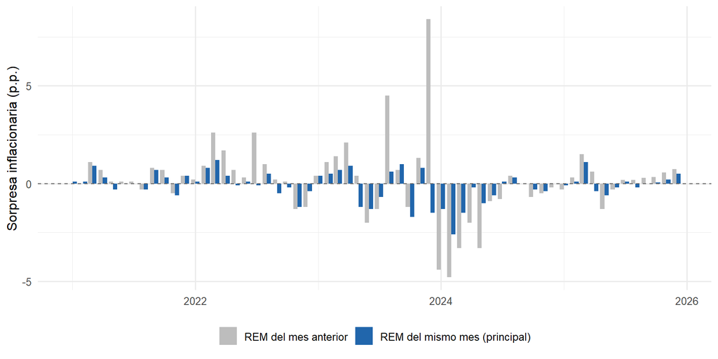

### 2.1.3 Validez del REM como expectativa de mercado

La capacidad del REM para anticipar el dato se evalúa con una regresión de Mincer-Zarnowitz,

$$\pi_{t}^{obs} = a + b\,\pi_{t}^{REM} +
u_{t}$$
(2)

con hipótesis conjunta de insesgadez $H_{0}: a = 0,\ b = 1$.

**Tabla 3.** Regresión de Mincer-Zarnowitz según la encuesta REM. Errores robustos (HC1).

| Encuesta | a | E.E. (a) | b | E.E. (b) | R² | F (a=0, b=1) | p-valor |
| --- | --- | --- | --- | --- | --- | --- | --- |
| Mismo mes (principal) | 0.310 | 0.102 | 0.928 | 0.020 | 0.977 | 6.618 | 0.003 |
| Mes anterior | 0.667 | 0.491 | 0.907 | 0.119 | 0.825 | 2.395 | 0.100 |

La encuesta del mismo mes explica casi toda la variación del IPC observado (R² = 0,977), con una pendiente de 0,928. Con esa precisión, el test conjunto detecta un desvío pequeño respecto de la insesgadez (p = 0,003): la sorpresa media es de -0,10 p.p., es decir, el REM sobreestimó levemente la inflación en promedio. La encuesta del mes anterior no rechaza la insesgadez (p = 0,100), pero con un ajuste bastante menor (R² = 0,825).

## 2.2 Nivel de retornos: estudio de eventos

El retorno normal de cada evento $e$ se modela con media constante (MacKinlay, 1997): $\hat\mu_{e}$ es el promedio de los retornos logarítmicos diarios en la ventana de estimación $[-120,-6]$ ruedas (el evento con menos historia dispone de 23 ruedas). El retorno anormal es $AR_{\tau} = r_{\tau} - \hat\mu_{e}$ y el retorno anormal acumulado $CAR_{e}(a,b) = \sum_{\tau=a}^{b} AR_{\tau}$. Se estima

$$CAR_{e}(-1,+1) = \alpha +
\beta_{1}\,Sorpresa_{e} + \varepsilon_{e}$$
(3)

con errores HC1, para ventanas alternativas, para el índice dolarizado con el CCL, con sorpresas positivas y negativas por separado, con interacción con el régimen posterior a diciembre de 2023 y para cada una de las siete acciones. En las acciones individuales también se usa media constante: el modelo de mercado (CAPM; Sharpe, 1964) queda como alternativa estándar, pero no se aplica al índice porque el Merval es la propia cartera de mercado.

## 2.3 Volatilidad condicional

La volatilidad diaria del Merval se modela con un AR(1)-GARCH(1,1) con innovaciones $t$-Student:

$$r_{t} = \mu + \phi\, r_{t-1} +
\varepsilon_{t}, \qquad \varepsilon_{t} = \sigma_{t} z_{t}, \qquad z_{t}
\sim t(\nu), \qquad \sigma_{t}^{2} = \omega +
\alpha_{1}\varepsilon_{t-1}^{2} + \beta_{1}\sigma_{t-1}^{2}$$
(4)

Por construcción, $\sigma_{t}$ depende solo de información hasta $t-1$: la noticia del día 0 recién puede reflejarse en la volatilidad condicional desde el día $+1$. Por eso la volatilidad del evento se mide hacia adelante. La especificación principal es

$$\bar{\sigma}_{e}(+1,+3) = \alpha +
\beta_{2}\,|Sorpresa_{e}| + \varepsilon_{e}$$
(5)

donde $\bar{\sigma}_{e}(a,b)$ es el promedio de $\hat\sigma_{t}$ entre los días $a$ y $b$. La velocidad de ajuste se evalúa comparando las ventanas $(+1,+1)$, $(+1,+3)$ y $(+1,+5)$; la ventana $[-1,+1]$ de la versión anterior se reporta por comparabilidad.

## 2.4 Signo de la sorpresa y contexto macroeconómico

La asimetría se estima separando la magnitud de las sorpresas positivas y negativas,

$$\bar{\sigma}_{e}(+1,+3) = \alpha +
\beta^{+}\,Sorpresa_{e}^{+} + \beta^{-}\,|Sorpresa_{e}^{-}| +
\varepsilon_{e}$$
(6)

y el papel del contexto con interacciones,

$$\bar{\sigma}_{e}(+1,+3) = \alpha +
\beta\,|Sorpresa_{e}| + \gamma\,Z_{e} + \delta\,(|Sorpresa_{e}| \times
Z_{e}) + \varepsilon_{e}$$
(7)

donde $Z_{e}$ es, alternativamente, el indicador de régimen (publicaciones desde el 10-dic-2023), el indicador de crisis cambiaria o el EMBI estandarizado medido cinco ruedas antes del evento. Un evento se clasifica como de crisis si se publica dentro de los 45 días posteriores a un salto diario del dólar oficial mayor al 10%; en la muestra hay tres saltos (14-ago-2023, 13-dic-2023 y 14-abr-2025) y 5 eventos en crisis (una ventana de 30 días clasifica los mismos eventos; la de 60 días, 7). La incertidumbre se mide con variables externas al proceso de volatilidad del índice para no introducir circularidad.

## 2.5 Estrategia de robustez

La ecuación (5) se somete a pruebas complementarias, que verifican un mismo resultado por caminos distintos y no constituyen hipótesis independientes: tests de permutación (Pearson y Spearman), regresión robusta de Huber, regresión cuantílica sobre la mediana, control por el VIX y por la volatilidad previa al evento, el cambio de volatilidad respecto de la semana anterior, una medida que no depende del GARCH (el shock estandarizado del día del anuncio, $|r_{0}|/\hat\sigma_{0}$), la sorpresa medida con el REM del mes anterior y la volatilidad estimada sobre la serie de Yahoo Finance.

## 2.6 Uso de Inteligencia Artificial Generativa

En la preparación de este trabajo se utilizó la herramienta de inteligencia artificial generativa Claude (Anthropic) como apoyo en la verificación de fuentes de datos, la construcción y depuración del código (Python para la base de datos y R para las estimaciones) y la redacción de secciones del texto. Las decisiones metodológicas, los análisis, la interpretación de los resultados y las conclusiones son responsabilidad de los autores, que verificaron la totalidad de la información presentada.

# 3. Resultados y discusión

## 3.1 Nivel de retornos

**Tabla 4.** Estimaciones de la ecuación (3). Variable dependiente: CAR del S&P Merval. Errores HC1.

| Especificación | Coeficiente | E.E. | p-valor | R² | n | Sig. |
| --- | --- | --- | --- | --- | --- | --- |
| Ventana [-1,+1] (principal) | 0.0111 | 0.0087 | 0.2038 | 0.028 | 60 |  |
| Ventana [0,+1] | 0.0126 | 0.0110 | 0.2569 | 0.042 | 60 |  |
| Ventana [-1,0] | 0.0019 | 0.0051 | 0.7171 | 0.002 | 60 |  |
| Ventana [-2,+2] | 0.0143 | 0.0120 | 0.2385 | 0.025 | 60 |  |
| Retorno crudo [-1,+1] | 0.0081 | 0.0089 | 0.3670 | 0.014 | 60 |  |
| Merval en dólares (CCL GGAL) | 0.0045 | 0.0091 | 0.6193 | 0.005 | 60 |  |
| Asimetría: sorpresa positiva | 0.0240 | 0.0217 | 0.2738 | 0.036 | 60 |  |
| Asimetría: sorpresa negativa | 0.0048 | 0.0094 | 0.6100 | 0.036 | 60 |  |
| Sorpresa × post-diciembre 2023 | 0.0060 | 0.0179 | 0.7405 | 0.063 | 60 |  |

**Tabla 5.** Ecuación (3) para acciones individuales. Variable dependiente: CAR $[-1,+1]$ de cada acción. Errores HC1.

| Especificación | Coeficiente | E.E. | p-valor | R² | n | Sig. |
| --- | --- | --- | --- | --- | --- | --- |
| GGAL — Banco (Galicia) | 0.0027 | 0.0093 | 0.7705 | 0.001 | 60 |  |
| BMA — Banco (Macro) | 0.0158 | 0.0096 | 0.1057 | 0.046 | 60 |  |
| YPFD — Energía (YPF) | 0.0074 | 0.0097 | 0.4453 | 0.008 | 60 |  |
| PAMP — Energía (Pampa) | 0.0150 | 0.0088 | 0.0922 | 0.048 | 60 | * |
| CEPU — Energía (Central Puerto) | 0.0169 | 0.0117 | 0.1563 | 0.034 | 60 |  |
| TXAR — Industria (Ternium) | 0.0192 | 0.0126 | 0.1343 | 0.043 | 60 |  |
| ALUA — Industria (Aluar) | 0.0104 | 0.0144 | 0.4748 | 0.012 | 60 |  |

Ningún corte del nivel de retornos muestra una reacción significativa al 5% a la sorpresa: ni las ventanas alternativas, ni el índice en dólares, ni la separación por signo, ni el cambio de régimen, ni las siete acciones (p-valor mínimo 0,092, PAMP — Energía (Pampa), significativo solo al 10% y aislado entre siete pruebas). El resultado coincide con el de la versión anterior, de modo que no depende de la fuente de precios ni de la encuesta REM utilizada.

## 3.2 Volatilidad condicional y velocidad de ajuste

**Tabla 6.** Modelo AR(1)-GARCH(1,1)-$t$ para los retornos diarios del S&P Merval (04-01-2021 a 27-02-2026, 1260 observaciones).

| Parámetro | Estimación | E.E. | p-valor |
| --- | --- | --- | --- |
| μ | 0.2906 | 0.0710 | 0.0000 |
| φ (AR1) | 0.1016 | 0.0288 | 0.0004 |
| ω | 0.3276 | 0.1211 | 0.0068 |
| α₁ | 0.0865 | 0.0228 | 0.0002 |
| β₁ | 0.8667 | 0.0334 | 0.0000 |
| ν (grados de libertad) | 7.6624 | 1.3266 | 0.0000 |

El modelo presenta la persistencia alta típica de mercados emergentes ($\hat\alpha_{1} + \hat\beta_{1} =$ 0,953) y colas pesadas ($\hat\nu =$ 7,66). Los residuos estandarizados no muestran autocorrelación (Ljung-Box, rezago 1: p = 0,426; rezago 5: p = 0,641).

**Tabla 7.** Ecuación (5) según la ventana de medición de la volatilidad. Variable dependiente: volatilidad condicional promedio. Errores HC1.

| Especificación | Coeficiente | E.E. | p-valor | R² | n | Sig. |
| --- | --- | --- | --- | --- | --- | --- |
| [-1,+1] (versión anterior) | 0.3167 | 0.1785 | 0.0812 | 0.064 | 60 | * |
| [+1] (día siguiente) | 0.3826 | 0.1712 | 0.0293 | 0.095 | 60 | ** |
| [+1,+3] (principal) | 0.3669 | 0.1533 | 0.0199 | 0.094 | 60 | ** |
| [+1,+5] | 0.3545 | 0.1494 | 0.0210 | 0.092 | 60 | ** |

**Figura 2.** Volatilidad condicional en los tres días posteriores al anuncio y magnitud de la sorpresa.

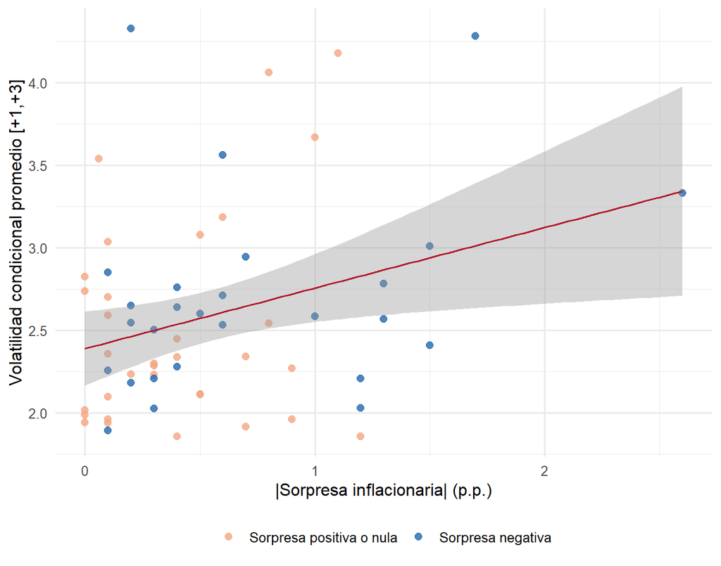

La magnitud de la sorpresa se asocia con una mayor volatilidad condicional en los días posteriores al anuncio (coef. = 0,3669, p = 0,020 en la ventana principal). El efecto aparece desde el primer día hábil y se mantiene estable al ampliar la ventana a cinco ruedas, lo que indica que el mercado incorpora la noticia como mayor incertidumbre de inmediato y que esa incertidumbre persiste al menos una semana. En la ventana $[-1,+1]$ de la versión anterior el coeficiente es menos preciso, porque dos de sus tres días son anteriores a que la noticia pueda afectar a $\hat\sigma_{t}$.

## 3.3 Signo de la sorpresa

**Tabla 8.** Ecuación (6). Variable dependiente: volatilidad condicional promedio $[+1,+3]$. Errores HC1.

| Especificación | Coeficiente | E.E. | p-valor | R² | n | Sig. |
| --- | --- | --- | --- | --- | --- | --- |
| Sorpresa positiva (inflación mayor a la esperada) | 0.3652 | 0.3643 | 0.3203 | 0.094 | 60 |  |
| \|Sorpresa negativa\| (inflación menor a la esperada) | 0.3672 | 0.1473 | 0.0156 | 0.094 | 60 | ** |

Los coeficientes de ambos signos son prácticamente iguales (0,365 para las sorpresas positivas y 0,367 para las negativas) y la igualdad no se rechaza (p = 0,995): no hay evidencia de asimetría. Solo el coeficiente de las sorpresas negativas resulta significativo porque se estima con más precisión: las sorpresas de mayor magnitud de la muestra fueron negativas, es decir, meses en que la inflación resultó menor a la esperada (27 de los 60 eventos), mientras que las positivas nunca superaron 1,2 p.p.

## 3.4 Contexto macroeconómico

**Tabla 9.** Ecuación (7). Coeficiente de la interacción $|Sorpresa| \times Z$. Variable dependiente: volatilidad condicional promedio $[+1,+3]$. Errores HC1.

| Especificación | Coeficiente | E.E. | p-valor | R² | n | Sig. |
| --- | --- | --- | --- | --- | --- | --- |
| Régimen (post-diciembre 2023) | -0.3275 | 0.3358 | 0.3336 | 0.235 | 60 |  |
| Crisis cambiaria (45 días) | -0.2311 | 0.3908 | 0.5567 | 0.160 | 60 |  |
| Crisis cambiaria (60 días) | 0.0831 | 0.4897 | 0.8658 | 0.179 | 60 |  |
| EMBI previo (estandarizado) | 0.3331 | 0.2690 | 0.2208 | 0.162 | 60 |  |

Ninguna de las medidas de contexto modifica de forma significativa la relación entre la sorpresa y la volatilidad (p-valor mínimo 0,221). Los datos no respaldan que el efecto sea más intenso en el régimen anterior a diciembre de 2023, en los episodios de crisis cambiaria o cuando el riesgo país es más alto. Con 5 eventos de crisis, sin embargo, la potencia para detectar esa diferencia es baja.

## 3.5 Robustez

**Tabla 10.** Pruebas de robustez del coeficiente de $|Sorpresa|$ en la ecuación (5).

| Especificación | Coeficiente | E.E. | p-valor | R² | n |
| --- | --- | --- | --- | --- | --- |
| Principal: ecuación (5) | 0.3669 | 0.1533 | 0.0199 | 0.094 | 60 |
| Permutación (Pearson, 5.000 réplicas) |  |  | 0.0122 |  |  |
| Permutación (Spearman, 5.000 réplicas) |  |  | 0.046 |  |  |
| Regresión robusta (Huber) | 0.3118 |  | 0.0158 |  |  |
| Regresión cuantílica (mediana) | 0.4378 |  | 0.0097 |  |  |
| Control por VIX | 0.3482 | 0.1731 | 0.049 | 0.1 | 60 |
| Control por volatilidad previa [-5,-1] | 0.1344 | 0.0866 | 0.1262 | 0.618 | 60 |
| Cambio de volatilidad ([+1,+3] menos [-5,-1]) | 0.0621 | 0.0919 | 0.5017 | 0.006 | 60 |
| Shock estandarizado del día 0, \|r₀\|/σ₀ | 0.3337 | 0.1663 | 0.0494 | 0.084 | 60 |
| Sorpresa con REM del mes anterior | 0.0831 | 0.0322 | 0.0124 | 0.039 | 60 |
| Volatilidad estimada con Yahoo Finance | 0.3695 | 0.1535 | 0.0193 | 0.096 | 60 |

El resultado resiste las pruebas que no dependen de supuestos de normalidad (permutación de Pearson, p = 0,012; de Spearman, p = 0,046), las que reducen el peso de los valores extremos (Huber, p = 0,016; cuantílica, p = 0,010), el control por riesgo global (p = 0,049) y la estimación con la serie de Yahoo Finance (p = 0,019). Sin las tres sorpresas de mayor magnitud la correlación cae de 0,306 a 0,131.

Dos pruebas obligan a matizar la interpretación. Al controlar por la volatilidad de la semana previa, el coeficiente se reduce y deja de ser significativo (p = 0,126), y tampoco es significativo el cambio de volatilidad respecto de esa semana (p = 0,502). Las sorpresas grandes tienden a ocurrir en períodos que ya eran volátiles, de modo que parte de la asociación refleja el estado del mercado y no solo la noticia. La prueba que aísla el día del anuncio, el retorno absoluto del día 0 dividido por la volatilidad esperada para ese día, sí muestra una relación positiva con la magnitud de la sorpresa (p = 0,049): el día de la publicación el mercado se mueve más de lo que anticipaba su propia volatilidad cuanto mayor es la sorpresa. Con la encuesta del mes anterior la asociación con la volatilidad también es significativa (p = 0,012), pero esa medida mezcla la noticia del IPC con información que el mercado ya conocía.

Por último, se estimó una especificación GARCH-X de un solo paso, con la magnitud de la sorpresa como regresor en la ecuación de varianza (distinto de cero solo el día de cada publicación). El coeficiente del regresor es 0,0000 con un error estándar robusto de 0,9667 (p = 1,000). Este enfoque tiene poca potencia cuando el regresor es distinto de cero en una fracción muy pequeña de la muestra diaria (60 de 1260 días) y el proceso es muy persistente, por lo que el enfoque en dos pasos se mantiene como especificación principal.

## 3.6 Síntesis por objetivo

**Tabla 11.** Resultados principales según los objetivos específicos.

| Objetivo | Evidencia |
| --- | --- |
| Velocidad de ajuste | Volatilidad mayor desde el día +1 y estable hasta +5 (p entre 0,020 y 0,029) |
| Signo de la sorpresa | Sin asimetría: coeficientes casi iguales por signo (igualdad, p = 0,995); solo el negativo es preciso |
| Contexto macroeconómico | Sin interacción significativa con régimen, crisis ni EMBI (p mínimo = 0,221) |
| Nivel de retornos (complementario) | Sin reacción al 5% en ninguna ventana, moneda, régimen ni acción (p mínimo = 0,092) |

En conjunto, la sorpresa inflacionaria no mueve el nivel de los retornos del Merval, pero su magnitud se asocia con una volatilidad más alta desde el día siguiente al anuncio, sin diferencias según el signo. El shock del día de la publicación es mayor cuanto mayor es la sorpresa, aunque buena parte de la asociación con la volatilidad de los días siguientes se superpone con el estado de volatilidad previo. Los datos no respaldan la hipótesis de que el efecto se intensifique en contextos de mayor incertidumbre macroeconómica.

# Anexo. Información de sesión